# Testis vs LCL comparison

Kushal K Dey

April 1, 2016

## Overview

In the GTEx V6 data, we find that LCL ans Testis together are part of the same cluster. It is difficult to connect the intuition behind why that would be so as they have seemingly pretty distinct origins. Also, when we thin the data, the Testis and LCL seem to be clustering separately. The intuition right now is for K=15 on unthinned data, the analysis could not separate out the two and formed a cluster that has representation from both the tissues. But since the testis specific genes are very prominent, it seems to be driven by those genes only (since they are the ones that get picked up among the top 5 genes).

```r
rm(list=ls())
library(data.table)
#install_github('kkdey/maptpx')
#install_github('kkdey/CountClust')
library(maptpx)
library(CountClust)
library(data.table)
library(ggplot2)
library(limma)
library(mygene)
library(knitr)
```

## Preparing Data

```r
data <- data.frame(fread('../external_data/GTEX_V6/cis_gene_expression.txt'));
```

```
##
Read 0.0% of 16069 rows
Read 62.2% of 16069 rows
Read 16069 rows and 8557 (of 8557) columns from 0.532 GB file in 00:00:11
```

```r
matdata <- data[,-(1:2)];
tissue_labels=read.table("../external_data/GTEX_V6/samples_id.txt")[,3];
```

We convert the counts to voom data.

```r
voom_data <- voom(matdata)$E;
```

## Expression vs cluster probability

We now compute the average voom expression for each gene across the LCL.

```r
voom_data_lcl <- voom_data[,grep("EBV", tissue_labels)]

mean_lcl_expr <- apply(voom_data_lcl,1, mean);
```

We now extract the theta matrix or the cluster probability expression.

```r
theta <- read.table("../external_data/GTEX_V6/admix_out_GTEX_V6/theta_cis_genes_0_1_2.txt",
                    header = TRUE, sep = " ",
                    stringsAsFactors = FALSE)

theta_expr_genes <- theta[,4];
```

We plot the theta expression against mean LCL expression.

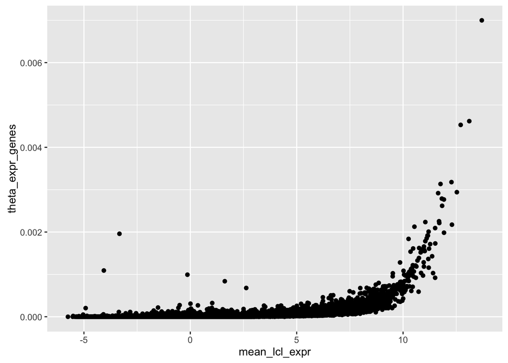

```r
qplot(mean_lcl_expr, theta_expr_genes)
```

## Annotating top expressed genes

It does seem from the above plot that genes with very high log expression pattern in LCLs also have higher cluster probability.

```r
gene_names <- read.table("../external_data/GTEX_V6/gene_names_GTEX_V6.txt")
lcl_genes <- gene_names[order(mean_lcl_expr, decreasing=TRUE)[1:100],1];

lcl_genes <- substring(lcl_genes,1,15);
out <- queryMany(as.character(lcl_genes),  scopes="ensembl.gene", fields=c("name", "summary"), species="human");
```

```
## Finished
## Pass returnall=TRUE to return lists of duplicate or missing query terms.
```

```r
kable(as.data.frame(out))
```

| X_id | name | summary | query |
| --- | --- | --- | --- |
| 60 | actin, beta | This gene encodes one of six different actin proteins. Actins are highly conserved proteins that are involved in cell motility, structure, and integrity. This actin is a major constituent of the contr… | ENSG00000075624 |
| 2597 | glyceraldehyde-3-phosphate dehydrogenase | This gene encodes a member of the glyceraldehyde-3-phosphate dehydrogenase protein family. The encoded protein has been identified as a moonlighting protein based on its ability to perform mechanistic… | ENSG00000111640 |
| 1915 | eukaryotic translation elongation factor 1 alpha 1 | This gene encodes an isoform of the alpha subunit of the elongation factor-1 complex, which is responsible for the enzymatic delivery of aminoacyl tRNAs to the ribosome. This isoform (alpha 1) is expr… | ENSG00000156508 |
| 567 | beta-2-microglobulin | This gene encodes a serum protein found in association with the major histocompatibility complex (MHC) class I heavy chain on the surface of nearly all nucleated cells. The protein has a predominantly… | ENSG00000166710 |
| 972 | CD74 molecule | The protein encoded by this gene associates with class II major histocompatibility complex (MHC) and is an important chaperone that regulates antigen presentation for immune response. It also serves a… | ENSG00000019582 |
| 71 | actin gamma 1 | Actins are highly conserved proteins that are involved in various types of cell motility, and maintenance of the cytoskeleton. In vertebrates, three main groups of actin isoforms, alpha, beta and gamm… | ENSG00000184009 |
| 2023 | enolase 1, (alpha) | This gene encodes alpha-enolase, one of three enolase isoenzymes found in mammals. Each isoenzyme is a homodimer composed of 2 alpha, 2 gamma, or 2 beta subunits, and functions as a glycolytic enzyme.… | ENSG00000074800 |
| 7178 | tumor protein, translationally-controlled 1 | NA | ENSG00000133112 |
| 6124 | ribosomal protein L4 | Ribosomes, the organelles that catalyze protein synthesis, consist of a small 40S subunit and a large 60S subunit. Together these subunits are composed of 4 RNA species and approximately 80 structural… | ENSG00000174444 |
| 6194 | ribosomal protein S6 | Ribosomes, the organelles that catalyze protein synthesis, consist of a small 40S subunit and a large 60S subunit. Together these subunits are composed of 4 RNA species and approximately 80 structural… | ENSG00000137154 |
| 1938 | eukaryotic translation elongation factor 2 | This gene encodes a member of the GTP-binding translation elongation factor family. This protein is an essential factor for protein synthesis. It promotes the GTP-dependent translocation of the nascen… | ENSG00000167658 |
| ENSG00000196205 | eukaryotic translation elongation factor 1 alpha 1 pseudogene 5 | NA | ENSG00000196205 |
| 6175 | ribosomal protein lateral stalk subunit P0 | Ribosomes, the organelles that catalyze protein synthesis, consist of a small 40S subunit and a large 60S subunit. Together these subunits are composed of 4 RNA species and approximately 80 structural… | ENSG00000089157 |
| 6122 | ribosomal protein L3 | Ribosomes, the complexes that catalyze protein synthesis, consist of a small 40S subunit and a large 60S subunit. Together these subunits are composed of 4 RNA species and approximately 80 structurall… | ENSG00000100316 |
| 5315 | pyruvate kinase, muscle | This gene encodes a protein involved in glycolysis. The encoded protein is a pyruvate kinase that catalyzes the transfer of a phosphoryl group from phosphoenolpyruvate to ADP, generating ATP and pyruv… | ENSG00000067225 |
| 6222 | ribosomal protein S18 | Ribosomes, the organelles that catalyze protein synthesis, consist of a small 40S subunit and a large 60S subunit. Together these subunits are composed of 4 RNA species and approximately 80 structural… | ENSG00000231500 |
| 3936 | lymphocyte cytosolic protein 1 (L-plastin) | Plastins are a family of actin-binding proteins that are conserved throughout eukaryote evolution and expressed in most tissues of higher eukaryotes. In humans, two ubiquitous plastin isoforms (L and … | ENSG00000136167 |
| 3122 | major histocompatibility complex, class II, DR alpha | HLA-DRA is one of the HLA class II alpha chain paralogues. This class II molecule is a heterodimer consisting of an alpha and a beta chain, both anchored in the membrane. It plays a central role in th… | ENSG00000204287 |
| 3106 | major histocompatibility complex, class I, B | HLA-B belongs to the HLA class I heavy chain paralogues. This class I molecule is a heterodimer consisting of a heavy chain and a light chain (beta-2 microglobulin). The heavy chain is anchored in the… | ENSG00000234745 |
| 6187 | ribosomal protein S2 | Ribosomes, the organelles that catalyze protein synthesis, consist of a small 40S subunit and a large 60S subunit. Together these subunits are composed of 4 RNA species and approximately 80 structural… | ENSG00000140988 |
| ENSG00000211899 | immunoglobulin heavy constant mu | NA | ENSG00000211899 |
| 3939 | lactate dehydrogenase A | The protein encoded by this gene catalyzes the conversion of L-lactate and NAD to pyruvate and NADH in the final step of anaerobic glycolysis. The protein is found predominantly in muscle tissue and b… | ENSG00000134333 |
| 6188 | ribosomal protein S3 | Ribosomes, the organelles that catalyze protein synthesis, consist of a small 40S subunit and a large 60S subunit. Together these subunits are composed of 4 RNA species and approximately 80 structural… | ENSG00000149273 |
| 203068 | tubulin beta class I | This gene encodes a beta tubulin protein. This protein forms a dimer with alpha tubulin and acts as a structural component of microtubules. Mutations in this gene cause cortical dysplasia, complex, wi… | ENSG00000196230 |
| 3326 | heat shock protein 90kDa alpha family class B member 1 | This gene encodes a member of the heat shock protein 90 family; these proteins are involved in signal transduction, protein folding and degradation and morphological evolution. This gene encodes the c… | ENSG00000096384 |
| 23521 | ribosomal protein L13a | Ribosomes, the organelles that catalyze protein synthesis, consist of a small 40S subunit and a large 60S subunit. Together these subunits are composed of 4 RNA species and approximately 80 structural… | ENSG00000142541 |
| 6202 | ribosomal protein S8 | Ribosomes, the organelles that catalyze protein synthesis, consist of a small 40S subunit and a large 60S subunit. Together these subunits are composed of 4 RNA species and approximately 80 structural… | ENSG00000142937 |
| 6137 | ribosomal protein L13 | Ribosomes, the organelles that catalyze protein synthesis, consist of a small 40S subunit and a large 60S subunit. Together these subunits are composed of 4 RNA species and approximately 80 structural… | ENSG00000167526 |
| 26986 | poly(A) binding protein, cytoplasmic 1 | This gene encodes a poly(A) binding protein. The protein shuttles between the nucleus and cytoplasm and binds to the 3’ poly(A) tail of eukaryotic messenger RNAs via RNA-recognition motifs. The bindin… | ENSG00000070756 |
| 6176 | ribosomal protein lateral stalk subunit P1 | Ribosomes, the organelles that catalyze protein synthesis, consist of a small 40S subunit and a large 60S subunit. Together these subunits are composed of 4 RNA species and approximately 80 structural… | ENSG00000137818 |

[output cut: 71 more lines]

## Are these genes actually meaningful?

If we go by the cluster probability, where will these genes land up in? The top three genes were PRM1, PRM2 and PHF7. How far down are these genes in that list then?

```r
top_features <- ExtractTopFeatures(as.matrix(theta), top_features=500, method="poisson", options="max");

top_genes_testis_lcl_cluster <- gene_names[top_features[4,],1];
top_genes_testis_lcl_cluster <- substring(top_genes_testis_lcl_cluster,1,15);

match(lcl_genes, top_genes_testis_lcl_cluster)
```

```
##   [1]  NA  NA  NA  NA  NA  NA  NA  NA  NA  12  NA  NA  NA  NA   4  NA  NA
##  [18]  NA  NA  40  NA  NA  44  NA  33  NA  25  NA  NA  NA  NA  93  29 171
##  [35]  NA  NA  NA  NA  NA  61  32  NA  NA  NA  NA   8  NA  NA  NA  NA  43
##  [52]  92  NA  NA  17 106  60  23  80  NA 162  NA  NA 105  NA  NA  63  NA
##  [69] 223  NA  NA  47  NA  NA  NA  NA  NA  20  NA 274  NA  NA  NA  62  NA
##  [86]  NA  NA  35 142  NA  84  NA  NA  37  NA 431  NA  NA  NA  NA
```

So we observe that of the top $100$ genes with highest LCL mean expression value, quite a few make it to the top features under extract top features function, and they are placed at 4th, 8th, 12th, 17th psotions which are pretty close to being top.

Lets annotate them.

```r
out <- queryMany(as.character(top_genes_testis_lcl_cluster[1:10]),  scopes="ensembl.gene", fields=c("name", "summary"), species="human");
```

```
## Finished
```

```r
kable(as.data.frame(out))
```

| name | X_id | summary | query |
| --- | --- | --- | --- |
| protamine 2 | 5620 | Protamines substitute for histones in the chromatin of sperm during the haploid phase of spermatogenesis, and are the major DNA-binding proteins in the nucleus of sperm in many vertebrates. They packa… | ENSG00000122304 |
| protamine 1 | 5619 | NA | ENSG00000175646 |
| PHD finger protein 7 | 51533 | Spermatogenesis is a complex process regulated by extracellular and intracellular factors as well as cellular interactions among interstitial cells of the testis, Sertoli cells, and germ cells. This g… | ENSG00000010318 |
| pyruvate kinase, muscle | 5315 | This gene encodes a protein involved in glycolysis. The encoded protein is a pyruvate kinase that catalyzes the transfer of a phosphoryl group from phosphoenolpyruvate to ADP, generating ATP and pyruv… | ENSG00000067225 |
| CD22 molecule | 933 | NA | ENSG00000012124 |
| coiled-coil domain containing 136 | 64753 | NA | ENSG00000128596 |
| semaphorin 7A (John Milton Hagen blood group) | 8482 | This gene encodes a member of the semaphorin family of proteins. The encoded preproprotein is proteolytically processed to generate the mature glycosylphosphatidylinositol (GPI)-anchored membrane glyc… | ENSG00000138623 |
| ribosomal protein S24 | 6229 | Ribosomes, the organelles that catalyze protein synthesis, consist of a small 40S subunit and a large 60S subunit. Together these subunits are composed of 4 RNA species and approximately 80 structural… | ENSG00000138326 |
| regulator of G-protein signaling 1 | 5996 | This gene encodes a member of the regulator of G-protein signalling family. This protein is located on the cytosolic side of the plasma membrane and contains a conserved, 120 amino acid motif called t… | ENSG00000090104 |
| CKLF like MARVEL transmembrane domain containing 2 | 146225 | This gene belongs to the chemokine-like factor gene superfamily, a novel family that links the chemokine and the transmembrane 4 superfamilies of signaling molecules. The protein encoded by this gene … | ENSG00000140932 |

So it does seem that the testis cluster indeed has a lot of representativeness from the LCL cluster.

So, we have got a few genes in the testis cluster which seem to have higher representativeness in LCL compared to other clusters. But how does the gene expression patterns for these genes look.

We investigate the genes which are in 4th and 7th positions in the list namely

### PKM gene (4th gene)

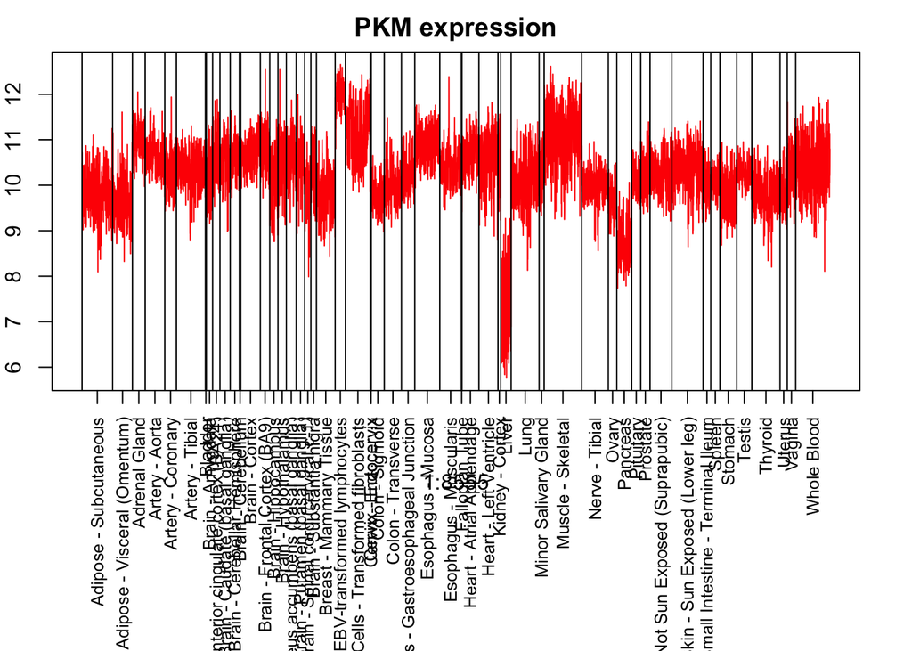

```r
index <- grep("ENSG00000067225", substring(gene_names[,1],1,15))
par(mfrow=c(1,1))
par(mar=c(10,2,2,2))
plot(1:8555, log(matdata[index,]+1), type="l", col="red",  ylab="log expr.", main="PKM expression", xaxt="n")

labels = match(unique(tissue_labels), tissue_labels);
abline(v=labels)

labels_low=labels;
labels_up=c(labels[2:length(labels)],8555);
mid_point=labels_low +0.5*(labels_up-labels_low);

axis(1,at=mid_point, unique(tissue_labels),las=3, cex.axis=0.8);
```

### SEMA7A (7th gene)

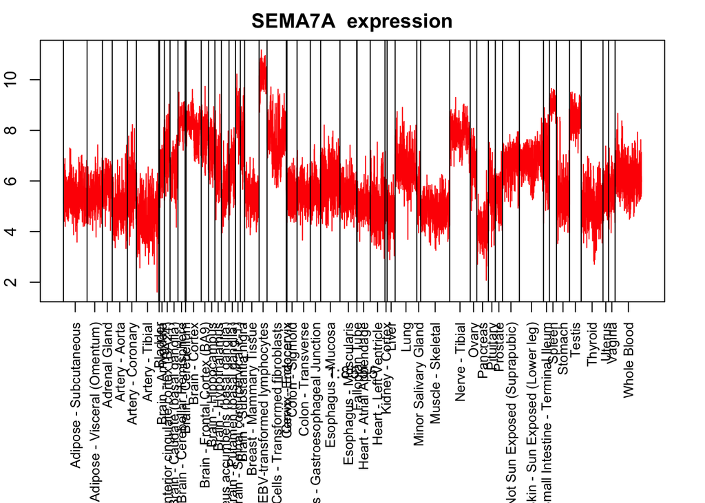

```r
index <- grep("ENSG00000138623", substring(gene_names[,1],1,15))
par(mfrow=c(1,1))
par(mar=c(10,2,2,2))
plot(1:8555, log(matdata[index,]+1), type="l", col="red",  ylab="log expr.", main="SEMA7A  expression", xaxt="n")

labels = match(unique(tissue_labels), tissue_labels);
abline(v=labels)

labels_low=labels;
labels_up=c(labels[2:length(labels)],8555);
mid_point=labels_low +0.5*(labels_up-labels_low);

axis(1,at=mid_point, unique(tissue_labels),las=3, cex.axis=0.8);
```